# Why Surveys?

Survey Research Methodology II, MUCSS

Dr. Marga Torre

margarita.torre@uc3m.es

## Outline

1. Why surveys? Advantages and limitations
2. New opportunities for data collection
3. The end of surveys?
4. Discussion
5. References

# Why surveys?

## The origin or surveys

1. **Historical Roots**: Survey research originated from practices like **census-taking** and **psychological testing** in the late 19th century. It evolved further during the 1920s with research on **attitudes** and social surveys of **urban poverty**
2. **Modern Survey Evolution**: In the mid-1930s, market researchers (e.g. Archibald Crossley, Elmo Roper, and George Gallup) transformed survey methods. They focused on **representing entire populations**, covering a wide range of topics, gathering timely data, and yielding **quantitative results**
3. **Academic Contributions**: Academics played a significant role in developing survey methods. In 1935, Lazarsfeld published [The art of asking why](https://www.jstor.org/stable/4291274) in the inaugural issue of the *National Marketing Review*.

## What? Why?

Surveys do more than just show what’s happening now. They also help us understand why people think, decide, and act the way they do:

- Surveys are powerful tools for describing characteristics, behaviors, and opinions of a specific population (**the “WHAT”**)
- Surveys are useful for exploring underlying reasons, motivations, and causes behind these observations (**the “WHY”**)

## Uses and importance

Zang and Cheng (2016), software engineers at Facebook, wrote:

*The goal of News Feed is to show you the stories that matter most to you. The actions people take on Facebook – liking, clicking, commenting or sharing a post – are historically some of the main factors considered to determine what to show at the top of your News Feed. But **these factors don’t always tell us the whole story of what is most meaningful to you**. As part of our ongoing eﬀort to improve News Feed, **we ask over a thousand people to rate their experience every day and tell us how we can improve the content they see** when they check Facebook – we call this our **Feed Quality Panel**. We also **survey tens of thousands of people around the world each day** to learn more about how well we’re ranking each person’s feed*

## Challenges in survey data collection

### Measurement and data quality

- Human memory limitations and recall errors
- Social desirability and cognitive biases
- Longitudinal challenges (attrition, inconsistency)
- Temporal effects (seasonality, timing)

### Coverage

- Underrepresentation of hard-to-reach groups
- Low response rates and survey fatigue
- Limited privacy or perceived lack of confidentiality
- Rising costs in traditional survey modes
- Inadequate adherence to survey methodology

# New opportunities for data collection

## New opportunities for data collection

Digital technologies have revolutionized social research by enabling new sources of information that are generated continuously and at scale. These include (among others):

- **Mobile devices**, which provide real-time data on behavior, mobility, and activity.
- **Online platforms**, which generate large volumes of data on preferences, interactions, and decisions.
- **Sensors and IoT devices**, which collect high-frequency environmental and physical measurements.
- **Electronic transaction data**, which capture actual economic behavior through digital payments.

Together, these sources allow researchers to observe behaviors and contexts that were previously difficult or impossible to measure.

## Digital trace data

### Opportunities

- Real-time data
- Reduced recall bias
- Behavioral validation
- Large-scale data

### Limitations

- Proprietary data
- Missing demographics
- Non-representativeness
- Ethical risks

## Example of propietary data

In his book [*Everybody Lies*](https://www.theguardian.com/technology/2017/jul/09/everybody-lies-how-google-reveals-darkest-secrets-seth-stephens-davidowitz) (Stephens-Davidowitz, 2018), the author uses Google search data to link racist search queries to electoral outcomes.

**Racial heatmap**: areas that strongly supported Trump also showed higher search intensity for racial slurs.

This approach is certainly intriguing. However, the data used are proprietary, raising concerns about transparency and replicability and limiting their use by restricting access for the general public.

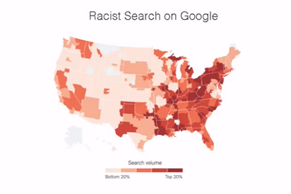

Racist heatmap

# The end of surveys?

## The end of surveys?

Rather than disappearing, **survey research is evolving**. We are witnessing a clear transition:

- from offline data collection methods to web-based surveys
- from web surveys to mobile surveys
- from outsourced market research to in-house research using do-it-yourself (DIY) web survey tools

## From surveys to rich data

Rich data involves extracting information by combining available tools and data sources in the most appropriate way. To this end, survey data are often analyzed together with:

- **Social media data**: a subset of internet data (text, images, videos) used to measure public opinion and attitudes.
- **Administrative data and registers**: large-scale data collected by government agencies (e.g. health, tax, benefits, pensions). Survey data can be linked to administrative records, a common practice in Nordic countries.
- **Paradata**: data describing the survey process itself, such as response times or item non-response.
- **Open polls and large-scale surveys**, such as:
  - [**Coronasurveys**](https://coronasurveys.org/): an application of the Network Scale-Up Method (NSUM) to estimate the size of hard-to-reach populations, particularly useful in epidemiology and public health. See also [here](https://www.frontiersin.org/articles/10.3389/fcomp.2021.641237/full).
  - [**EU-LGBT Survey**](https://fra.europa.eu/en/publication/2014/eu-lgbt-survey-european-union-lesbian-gay-bisexual-and-transgender-survey-main): a large-scale survey conducted by the EU Agency for Fundamental Rights (FRA).

# Discussion

## Key takeaways

- Surveys are well suited for targeted research focused on opinions and socio-demographic characteristics, but they can be limited by bias and high implementation costs.
- Big Data offers scale, speed, and cost efficiency, yet often lacks specificity, detailed socio-demographic information, and the ability to establish causal relationships.

Each approach has distinct strengths and limitations, and the choice between them should be guided by the specific objectives of the research question.

Against this backdrop, **the goal of this course is to introduce and develop key strategies — such as handling missing data, survey experiments using paradata or AI — to address the main challenges of survey analysis and to extract the maximum possible value from survey data**

## To debate

**Survey professionalism?**

Online panels are a key resource for social science research. While these panels offer valuable data, the financial incentives involved may encourage respondents to become “survey professionals,” raising concerns about data quality.

To address this issue, the article provides evidence of survey professionalism by analyzing behavioral web browsing data from three U.S. samples, recruited through Lucid (now [Cint](https://www.cint.com/)), [YouGov](https://today.yougov.com/about/panel), and Facebook (total n = 3,886).

[Survey Professionalism: New Evidence from Web Browsing Data](https://osf.io/preprints/osf/jxdc8)

# References

## References of interest

- Gray, E., Jennings, W., Farrall, S. and C. Hay. 2015. Small Big Data: Using Multiple Data-Sets to Explore Unfolding Social and Economic Change. Big Data & Society 2(1).
- Japec, L., Kreuter, F., Berg, M., Biemer, P., Decker, P., Lampe, C., Lane, J., O’Neil, C. and A. Usher. 2015. “Big Data in Survey Research. AAPOR Task Force Report.” Public Opinion Quarterly 79(4): 839–80
- Stephens-Davidowitz, S., 2018. Everybody lies: What the internet can tell us about who we really are. Bloomsbury Publishing.
- Vannette, D.L. and Krosnick, J.A. eds., 2017. The Palgrave handbook of survey research. Springer
- Zhang, Chen, and Si Chen. 2016. “News Feed FYI: Using Qualitative Feedback to Show Relevant Stories.” February 1.

Master in Computational Social Sciences (UC3M)